# Week 6 / Day 5

## MVP

```r
library(tidyverse)
library(infer)
data(msleep)
```

## 1.1

### Q1.

Explore the dataset and familiarise yourself with it.

```r
glimpse(msleep)
```

```
Rows: 83
Columns: 11
$ name         <chr> "Cheetah", "Owl monkey", "Mountain beaver", "Greater short-tailed s…
$ genus        <chr> "Acinonyx", "Aotus", "Aplodontia", "Blarina", "Bos", "Bradypus", "C…
$ vore         <chr> "carni", "omni", "herbi", "omni", "herbi", "herbi", "carni", NA, "c…
$ order        <chr> "Carnivora", "Primates", "Rodentia", "Soricomorpha", "Artiodactyla"…
$ conservation <chr> "lc", NA, "nt", "lc", "domesticated", NA, "vu", NA, "domesticated",…
$ sleep_total  <dbl> 12.1, 17.0, 14.4, 14.9, 4.0, 14.4, 8.7, 7.0, 10.1, 3.0, 5.3, 9.4, 1…
$ sleep_rem    <dbl> NA, 1.8, 2.4, 2.3, 0.7, 2.2, 1.4, NA, 2.9, NA, 0.6, 0.8, 0.7, 1.5, …
$ sleep_cycle  <dbl> NA, NA, NA, 0.1333333, 0.6666667, 0.7666667, 0.3833333, NA, 0.33333…
$ awake        <dbl> 11.9, 7.0, 9.6, 9.1, 20.0, 9.6, 15.3, 17.0, 13.9, 21.0, 18.7, 14.6,…
$ brainwt      <dbl> NA, 0.01550, NA, 0.00029, 0.42300, NA, NA, NA, 0.07000, 0.09820, 0.…
$ bodywt       <dbl> 50.000, 0.480, 1.350, 0.019, 600.000, 3.850, 20.490, 0.045, 14.000,…
```

### Q2.

Jabberwockies sleep for around 7 hours a night, on average. Perform an appropriate statistical test to determine whether the mean sleep_total in the sampled population of animal types differs from the typical value for jabberwockies.

#### Step 1 / Define

Test: One Sample Mean Test

Question: Is there a statistically significant difference between the mean total sleep time of Jabberwockies (said to be 7 hours per night) and the mean total sleep time of the animals in the sample?

Hypothesis (Text): H0: sample_mean_sleep_total = 7 H1: sample_mean_sleep_total != 7

Hypothesis (Mathmatecal Notation): H0: $\mu$ == 7 H1: $\mu$ $\neq$ 7

Method for Generating Null Distribution: Bootstrap

Significance Level: 0.05

#### Step 2. Calculate Observed Statistic

The observed statistic will be the mean `sleep_total` for all observations in our sample.

```r
observed_statistic_q2 <- msleep %>%
  summarise(mean_sleep_total = mean(sleep_total))

observed_statistic_q2
```

| mean_sleep_total |
| --- |
| 10.43373 |

#### Step 3 / Create Null Distribution

Now we will create our Null distribution - creating a distribution where H0 is true (eg. the mean `sleep_total` is 7, the same as Jabberwockies).

```r
null_distribution_q2 <- msleep %>%
  specify(response = sleep_total) %>%
  hypothesize(null = "point", mu = 7) %>%
  generate(reps = 50000, type = "bootstrap") %>%
  calculate(stat = "mean")

null_distribution_q2
```

```
Response: sleep_total (numeric)
Null Hypothesis: point
```

| replicate | stat |
| --- | --- |
| 1 | 7.569880 |
| 2 | 7.536145 |
| 3 | 7.001205 |
| 4 | 6.698795 |
| 5 | 7.132530 |
| 6 | 7.225301 |
| 7 | 7.526506 |
| 8 | 7.172289 |
| 9 | 7.060241 |
| 10 | 7.192771 |

[output cut: 990 more lines]

#### Step 4 / Visualise Observed Statistic on NULL Distribution

Now we to visualise our observed statistic on our Null distribution to get a sense for how extreme it may be, if H0 was to be true. We set the direction argument to `both` as our question is only interested in with whether there is a difference and not if the difference is positive or negative.

In the output we can already see that our observed stat appears to be pretty extreme and therefore unlikely to occur if H0 was true.

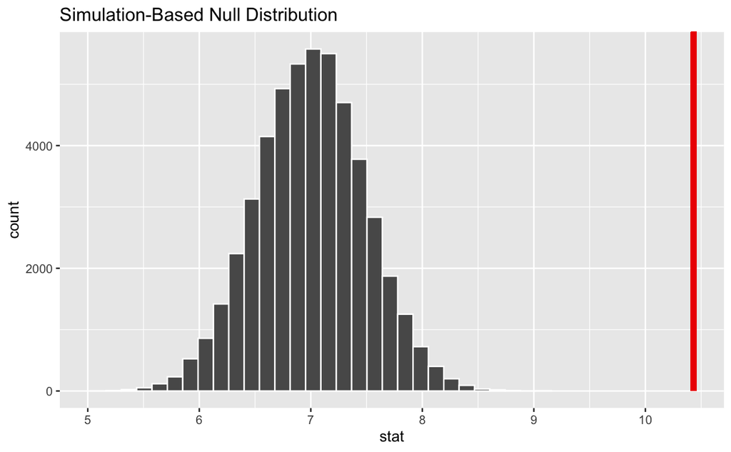

```r
null_distribution_q2 %>%
  visualise(bins = 30) +
  shade_p_value(obs_stat = observed_statistic_q2,
                direction = "both")
```

#### Step 5 / Calculate P Value

```r
p_value <- null_distribution_q2 %>%
  get_p_value(obs_stat = observed_statistic_q2,
              direction = "both")
```

```
Warning: Please be cautious in reporting a p-value of 0. This result is an approximation based on the number of `reps` chosen in the `generate()` step. See `?get_p_value()` for more information.
```

In this instance the p-value is returned as 0 which is lower than our set significance level of 0.05. We therefor reject H0 which stated that there was no significant difference between the mean `sleep_total` between Jabberwockies and the animals in our sample.

The p-value is the probability of calculating the observed statistic, or one more extreme, if H0 is true. Therefor, in this instance a p-value of 0 tells us that there is an extremely low probabability of the observed statistic, or one more extreme, being calculated if H0 is true. Therefor, based on statistical significance, there is strong evidence for rejecting H0 and suggesting that there is a statistically significant difference in the mean `sleep_total` of Jabberwockies and the animals in our sample.

NB - In this question after reading the warning message about reporting a p-value of zero and reading the documentation, I did try increasing the number of replicates in my generate; however, I was still unable to calculate a different p-value.

### Q3.

Perform an appropriate statistical test to determine whether omnivores sleep for significantly longer than herbivores, on average.

#### Step 1 / Define

Test: Two Sample Mean Test (Independent) Question: Perform an appropriate statistical test to determine whether omnivores sleep for significantly longer than herbivores, on average.

Hypothesis (Text): H0: omnivore_mean_sleep_total - herbivore_mean_sleep_total == 0 H1: omnivore_mean_sleep_total - herbivore_mean_sleep_total > 0

Hypothesis (Mathmatecal Notation): H0: $\mu{1}$ - $\mu{2}$ == 0 H1: $\mu{1}$ - $\mu{2}$ > 0

Method for Generating Null Distribution: Permute

Significance Level: 0.05

#### Step 2. Calculate Observed Statistic

First we will filter our sample to only contain Omnivores and Herbivores since these are the animals that we’re interested in.

```r
msleep_filtered_q3 <- msleep %>%
  filter(vore %in% c("omni", "herbi"))

msleep_filtered_q3
```

| name | genus | vore | order | conservation | sleep_total | sleep_rem | sleep_cycle | awake | brainwt | bodywt |
| --- | --- | --- | --- | --- | --- | --- | --- | --- | --- | --- |
| Owl monkey | Aotus | omni | Primates | NA | 17.0 | 1.8 | NA | 7.0 | 0.01550 | 0.480 |
| Mountain beaver | Aplodontia | herbi | Rodentia | nt | 14.4 | 2.4 | NA | 9.6 | NA | 1.350 |
| Greater short-tailed shrew | Blarina | omni | Soricomorpha | lc | 14.9 | 2.3 | 0.1333333 | 9.1 | 0.00029 | 0.019 |
| Cow | Bos | herbi | Artiodactyla | domesticated | 4.0 | 0.7 | 0.6666667 | 20.0 | 0.42300 | 600.000 |
| Three-toed sloth | Bradypus | herbi | Pilosa | NA | 14.4 | 2.2 | 0.7666667 | 9.6 | NA | 3.850 |
| Roe deer | Capreolus | herbi | Artiodactyla | lc | 3.0 | NA | NA | 21.0 | 0.09820 | 14.800 |
| Goat | Capri | herbi | Artiodactyla | lc | 5.3 | 0.6 | NA | 18.7 | 0.11500 | 33.500 |
| Guinea pig | Cavis | herbi | Rodentia | domesticated | 9.4 | 0.8 | 0.2166667 | 14.6 | 0.00550 | 0.728 |
| Grivet | Cercopithecus | omni | Primates | lc | 10.0 | 0.7 | NA | 14.0 | NA | 4.750 |
| Chinchilla | Chinchilla | herbi | Rodentia | domesticated | 12.5 | 1.5 | 0.1166667 | 11.5 | 0.00640 | 0.420 |

[output cut: 42 more lines]

```r
NA
```

Next I will calculate our observed stat, which is the difference in average sleep between Omnivores and Herbivores from our sample.

```r
observed_stat_q3 <- msleep_filtered_q3 %>%
  specify(response = sleep_total, explanatory = vore) %>%
  calculate(stat = "diff in means", order = c("omni", "herbi"))

observed_stat_q3
```

```
Response: sleep_total (numeric)
Explanatory: vore (factor)
```

| stat |
| --- |
| 1.415625 |

#### Step 3 / Create Null Distribution

Next we create our Null distribution - which is to create a distribution where there is no difference in the mean sleep_total between Omnivores and Herbivores.

```r
null_distribution_q3 <- msleep_filtered_q3 %>%
  specify(response = sleep_total, explanatory = vore) %>%
  hypothesize(null = "independence") %>%
  generate(reps = 1000, type = "permute") %>%
  calculate(stat = "diff in means", order = c("omni", "herbi"))

null_distribution_q3
```

```
Response: sleep_total (numeric)
Explanatory: vore (factor)
Null Hypothesis: independence
```

| replicate | stat |
| --- | --- |
| 1 | 0.993125 |
| 2 | 1.789375 |
| 3 | -2.045625 |
| 4 | 0.205000 |
| 5 | -0.493750 |
| 6 | -2.037500 |
| 7 | -0.160625 |
| 8 | -1.623125 |
| 9 | 0.660000 |
| 10 | 0.213125 |

[output cut: 990 more lines]

#### Step 4 / Visualise Observed Statistic on Null Distribution

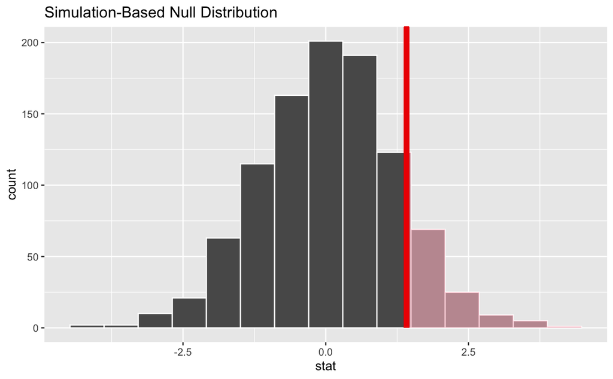

```r
null_distribution_q3 %>%
  visualise() +
  shade_p_value(obs_stat = observed_stat_q3, direction = "right")
```

#### Step 5 / Calculate P Value

```r
p_value <- null_distribution_q3 %>%
  get_p_value(obs_stat = observed_stat_q3, direction = "right")

p_value
```

| p_value |
| --- |
| 0.121 |

In this instance the p-value is returned as 0.121 which is higher than our set significance level of 0.05. We therefor fail to reject the H0 which stated that there was no difference between the mean sleep_total of Omnivores and Herbivores.

The p-value is the probability of calculating the observed statistic, or one more extreme, if H0 is true. Therefor, in this instance a p-value of 0.121 tells us that there is a 12% probability of the observed statistic, or one more extreme, being calculated if H0 is true. Therefore, based on statistical significance, there is weak evidence for rejecting H0 and suggesting that Omnivores sleep significantly longer than Herbivores.

### Q4.

Perform an appropriate statistical test to determine whether the proportion of domesticated animal types in the population of animal types is greater than 5%.

#### Step 1 / Define

Test: One Sample Proportion Test Question: Perform an appropriate statistical test to determine whether the proportion of domesticated animal types in the population of animal types is greater than 5%.

Hypothesis (Text): H0: domesticated_animal_proportion == 5 H1: domesticated_animal_proportion > 5

Hypothesis (Mathmatecal Notation): H0: $\pi$ == 5 H1: $\pi$ > 5

Method for Generating Null Distribution: Draw

Significance Level: 0.05

#### Step 2. Calculate Observed Statistic

```r
observed_stat_q4 <- msleep %>%
  group_by(conservation) %>%
  summarise(proportion = n()/nrow(msleep)) %>%
  filter(conservation == "domesticated")

observed_stat_q4
```

| conservation | proportion |
| --- | --- |
| domesticated | 0.1204819 |

#### Step 3 / Create Null Distribution

Next we will create an `is_domesticated` variable which will contain the value, “Domesticated” or “Not Domesticated”. This will create a categorical variable with only two possible answers which is needed to generate an appropriate Null distribution.

```r
# Here I have decided to drop any observations where the `conservation` value is missing (eg. NA). An alternative approach would be to consider these as not domesticated as otherwise "domesticated" would have been entered. However, rather than make this assumption, I have decided to drop these observations.

msleep_tidy <- msleep %>%
  drop_na(conservation)

# Next, I create a new `is_domesticated` variable with only two possible values.

msleep_tidy <- msleep_tidy %>%
  mutate(is_domesticated =
           if_else(conservation == "domesticated", "domesticated", "not domesticated"))

# Finally, I create a Null distribution from this data.

null_distribution_q4 <- msleep_tidy %>%
  specify(response = is_domesticated, success = "domesticated") %>%
  hypothesize(null = "point", p = 0.05) %>%
  generate(reps = 5000, type = "draw") %>%
  calculate(stat = "prop")

null_distribution_q4
```

```
Response: is_domesticated (factor)
Null Hypothesis: point
```

| replicate | stat |
| --- | --- |
| 1 | 0.03703704 |
| 2 | 0.07407407 |
| 3 | 0.01851852 |
| 4 | 0.01851852 |
| 5 | 0.05555556 |
| 6 | 0.01851852 |
| 7 | 0.05555556 |
| 8 | 0.05555556 |
| 9 | 0.03703704 |
| 10 | 0.00000000 |

[output cut: 990 more lines]

#### Step 4 / Visualise Observed Statistic on Null Distribution

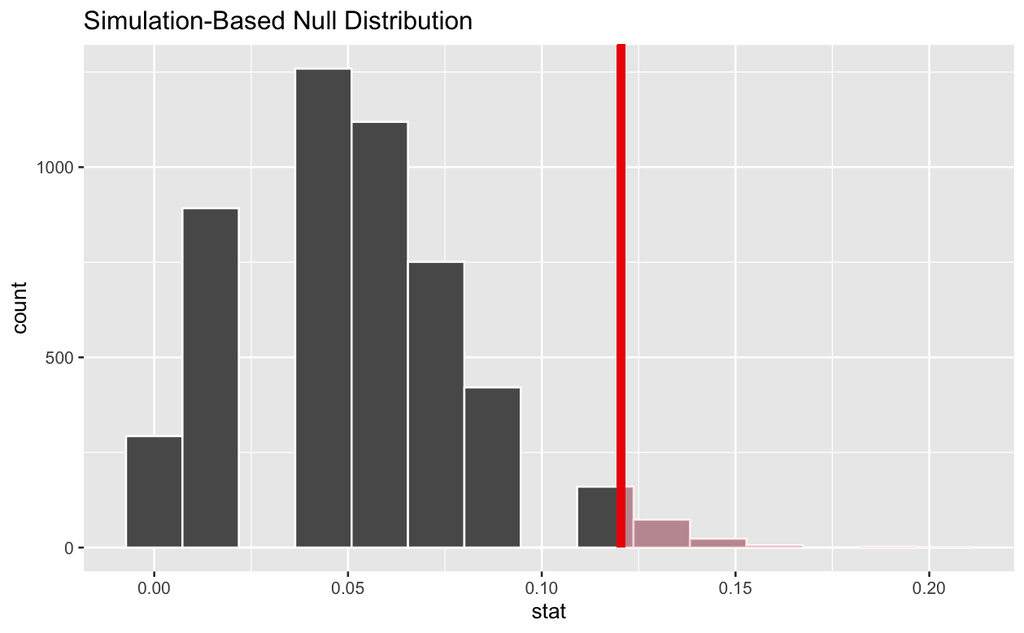

```r
null_distribution_q4 %>%
  visualise() +
  shade_p_value(obs_stat = observed_stat_q4$proportion, direction = "right")
```

#### Step 5 / Calculate P Value

```r
p_value <- null_distribution_q4 %>%
  get_p_value(observed_stat_q4$proportion, direction = "right")

p_value
```

| p_value |
| --- |
| 0.021 |

In this instance the p-value is returned as 0.021 which is lower than our set significance level of 0.05. We therefor reject H0 which stated that the proportion of domesticated animal types in the population of animal types was 5%.

The p-value is the probability of calculating the observed statistic, or one more extreme, if H0 is true. Therefor, in this instance a p-value of 0.021 tells us that there is a 2.1% probability of the observed statistic, or one more extreme, being calculated if H0 is true. Therefore, based on statistical significance, there is strong evidence for rejecting H0 and suggesting that that the proportion of domesticated animal types in the population of animal types is not 5%.

## 1.2 & 1.3

### Q1.

You work for a independent coffee shop. The boss tells you that she thinks that around 40% of people in the town (population 30,000) know of the coffee shop, but you are skeptical of the estimate and think that the actual percentage is higher. You conduct a random survey of 200 people in the town, asking if respondents are aware of your coffee shop. You want to use the sample to test the hypothesis that more than 40% of the town’s population have heard of the coffee shop.

Test: One Sample Proportion Test Hypothesis (Text):

H0: Percentage of people who know of the coffee shop == 40 H1: Percentage of people who know of the coffee shop > 40

Hypothesis (Mathematical Notation): H0: $\pi$ == 40 H1: $\pi$ > 40

Method for Generating Null Distribution: Draw

Results: Significance level: 0.05, calculated p-value: 0.07

Interpretation: In this instance the p-value is returned as 0.07 which is higher than our set significance level of 0.05. We therefor fail to reject the H0 which stated that the proportion of people in the town who know about the coffee shop is 40%.

The p-value is the probability of calculating the observed statistic, or one more extreme, if H0 is true. Therefor, in this instance a p-value of 0.07 tells us that there is a 7% probability of the observed statistic, or one more extreme, being calculated if H0. Therefore, based on statistical significance, there is weak evidence for rejecting H0 and suggesting that the proportion of people in the town who know about the coffee shop is not 40%.

### Q2.

You work for a website design company and have performed an A/B test on the position of a banner on a website promoting a particular item.

You selected five days at random last month and then randomly selected 200 of each sampled day’s users into group A and another 200 of that day’s users into group B. Group A continued to be shown the banner at the right hand side of the webpage (its usual position) while group B was shown the banner at the top of the page. You monitored each sampled user’s interactions with the website, in particular the ‘click through rate’ (CTR) on the banner, i.e. what proportion of sampled users clicked on the banner. You want to use the sampled data to test the hypothesis that website users overall are more likely to click on the banner if positioned at the top of the page

Test: Two Sample Proportion Test

Hypothesis (Text):

H0: CTR Group B - CTR Group A = 0 H1: CTR Group B - CTR Group A > 0

Hypothesis (Mathmatecal Notation):

H0: $\pi{2}$ - $\pi{1}$ == 0 H1: $\pi{2}$ - $\pi{1}$ > 0

Method for Generating Null Distribution: Permute

Results: Significance level: 0.01, p-value: 0.006

### Q3.

You work as an analyst for a car manufacturing company - they have specific standards they must meet for standards and regulation purposes. You have been asked to check the quality control of the manufacture of a particular car part. You have been given data on a sample of 200 parts produced over the period of a week (the sampled parts were pulled at random from the production line and measured: the factory produced a lot more than 200 parts that week). The specification of the part stipulates a width of 145mm, and the manufacturing process is said to have ‘drifted’ if the mean width of parts differs significantly from 145mm. You want to use the sampled measurements to test whether the process overall has drifted.

Test: One Sample Mean Test

Hypothesis (Text):

H0: mean_width - 145 == 0 H1: mean_width - 145 != 0

Hypothesis (Mathmatecal Notation):

H0: $\mu$ - 145 = 0 H1: $\mu$ - 145 $\neq$ 0

Method for Generating Null Distribution: Bootstrap

Results: Significance level: 0.05, p-value: 0.55

Interpretation: In this instance the p-value is returned as 0.55 which is higher than our set significance level of 0.05. We therefor fail to reject the H0 which stated that there was no difference between the mean width of the part and the stipulated width of 145mm.

The p-value is the probability of calculating the observed statistic, or one more extreme, if H0 is true. Therefor, in this instance a p-value of 0.55 tells us that there is a 55% probability of the observed statistic, or one more extreme, being calculated if H0 is true. Therefore, based on statistical significance, there is weak evidence for rejecting H0 and suggesting that there is a significant difference.